# Course Notes

# 1 Chapter 0: Getting Started

## 1.1 True Cost of Emplyee Turnover

### 1.1.1 Employee Turnover: A $15M Problem

Differentiating between productive and non-productive employees is difficult and highly subjective. Some employees are in the top 20% (all stars), some are in the middle 60% (productive), and some are in the bottom 20%. The bottom 20% can be OK or can be poor depending on the overall level of talent in your organization. Sometimes just because they are bottom 20% they are still good employees because the organization is such a high performing organization that everyone they employee is good. However, most organizations do have bad employees.

Now, in terms of defining productivity, if on a 1 to 4 scale with 1 being poor and 4 being the best that managers rate employees 3 to 4, you can usually be OK in viewing the 4’s as productive. They may not always be all stars, especially if 50% of people reviewed get 4’s but in reality only 20% should by the bell curve. However, if a manager rates someone as a 1, there is definitely a problem. These people need to either have immediate corrective actions taken or need to be cut loose. This is good attrition because the employee is a poor job/culture fit.

The analysis we are doing specifically looks at bad attrition, losing people that are 3’s and 4’s. I call them high performers, but in reality, I should be saying productive employees. This group is probably driving 80% of the business results.

Non-profits will need to be handled based on what the business finds important. While maximizing profit may not be the goal, there are still goals. For example, one goal might be to increase high school graduation rates in schools. This could be set up showing that the percentage of student dropouts are much higher in the district of focus and that increasing graduation rates is expected to reduce crime and increase workforce productivity. Crime reduction would have a savings associated with it. Workforce productivity would have a financial benefit associated with it. These are possible ways we can show financial value for a non-profit.

Non-Profit Cost Analysis: https://www.bridgespan.org/bridgespan/Images/articles/nonprofit-cost-analysis-toolkit/NonprofitCostsAnalysisToolkit.pdf

Non-Profit Strategic Planning: https://knowhownonprofit.org/organisation/strategy

The tools are quite similar to what you might find in a for-profit scenario. The maximization will be to maximize the financial delta between cost and benefit (to public) versus cost and revenue (for organization).

### 1.1.2 What Happens When Good Emplyees Leave

*You takeaway our top 20 employees and we become a mediocre company* –Bill Gates

- All emplyees turnover, some just faster
- Impact of Attrition
  - Varies based on employee productivity
  - Can be measured
- Bad turnover costs the organization

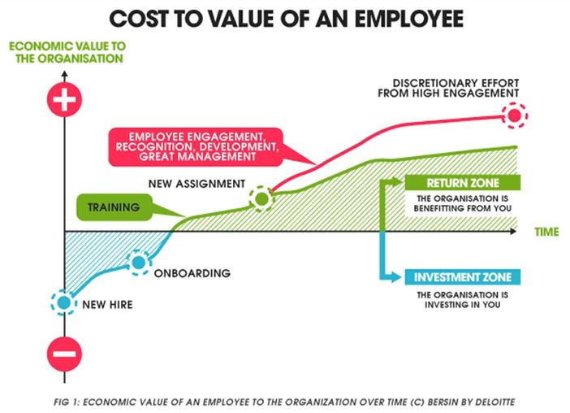

[Employee Retention Now a Big Issue: Why the Tide has Turned](https://www.linkedin.com/pulse/20130816200159-131079-employee-retention-now-a-big-issue-why-the-tide-has-turned/)

When a good employee quits, costs are incurred.

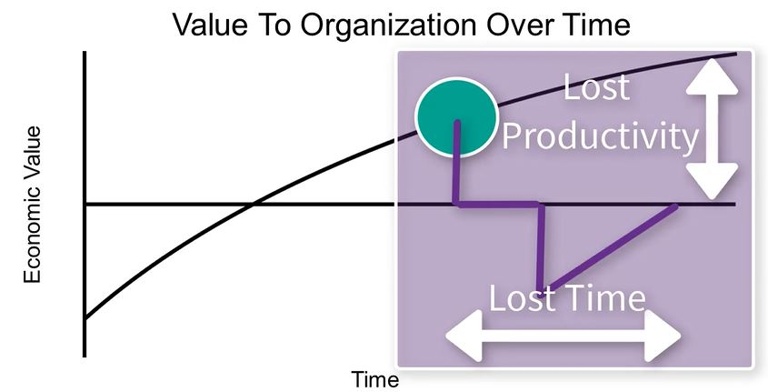

- Quits
- Vacancy durinfg search
- Cost to train new employee

Not all attrition is bad

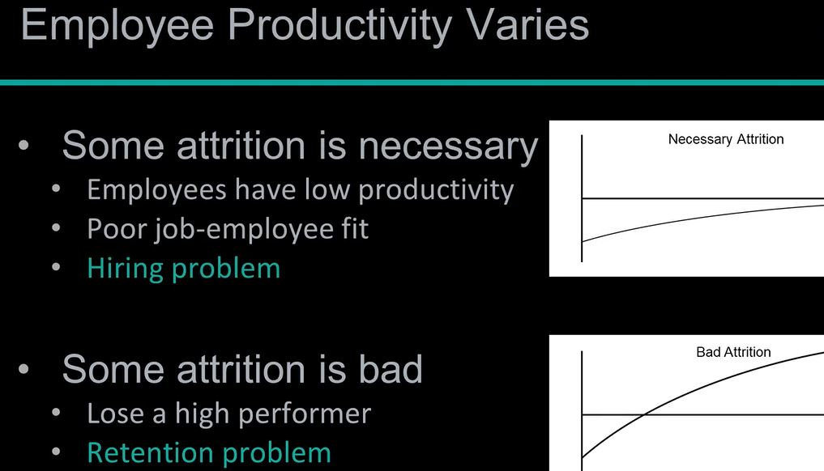

### 1.1.3 Calculating the Cost of Turnover

- Direct Costs
  - Average Separation (Exit Interviews, Separation Pay, Admin Costs) ($500)
  - Average Vacancy (Temp Help & OT) ($10,000)
  - Average Acquisition (Ads, Travel, Interviews, Physicals, Drug Testing, Bonuses, Reference Checks, etc) ($4,900)
  - Average Placement (New Supplies, Onboarding, Training) ($3,500)

$$500+10,000+4,900+3,500=18,900$$

- Productivity Costs (Hidden Costs - only recognized when the problem becomes large. Much higher than direct costs.)
  - Annual revenue per Employee - less COGS (250,000)
  - Workdays per Year (240)
  - Average Workdays Position Open (40)
  - Average Onboarding/Training Period (60 ~ 12 weeks)
  - Effectiveness During Onboarding/Training (50%)

$$(250,000/240)*(40+(60*.5))=72,917$$

- Salary & Benefits
  - Average Salary + Benefits (80,000)
  - Workdays per Year (240)
  - Average Workdays Position Open (40)

> Just a 10% reduction (using data science) saves the organization $1.6M/year!

## 1.2 Chapter 0.3: What Tools Are In Our Toolbox?

### 1.2.1 Integrated Data Science Frameworks: BSPF & CRISP-DM

Business Science Problem Framework

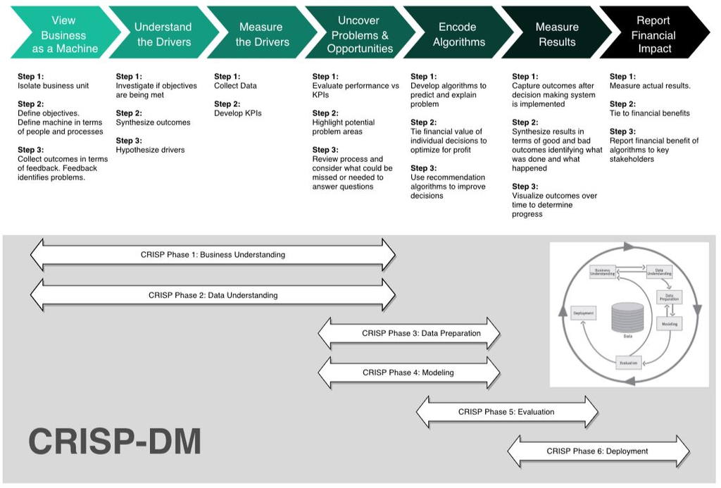

- Framwork provide
  - Consistency across projects
  - Critical Step Checklist
  - Clarity to stakeholders
  - Keeps project on track

BSPF is aligned with industry standard CRISP-DM

## 1.3 Chapter 0.4 Frameworks

### 1.3.1 CRISP-DM

[CRISP-DM](https://www.the-modeling-agency.com/crisp-dm.pdf) is a high level indistry-standard framework for data mining.

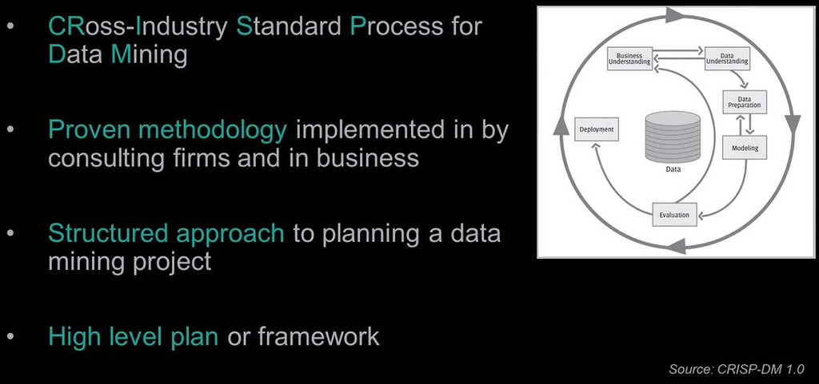

> A high level plan that is adapatable but lacks the detail to drive data science projects

CRISP-DM Process Cycle

1. Business Understanding
   - Critical - sets stage for all downstream events
   - Problem solving and project scope development with the business
   - Combines discovery and prject management
   - Documents current state and the business success metric
2. Data Understanding
   - 20% of project time typically consumed by data collection
3. Data Preparation
   - 60% of your time cleaning and organizing data
4. Modeling
   - information turned into insight
   - Model Understnading
   - Model Assessment
5. Evaluation
   - Assess degree which the data insights meet business objectives (ROI)
6. Deployment
   - REST API
   - Shiny App
   - Markdown file output

### 1.3.2 Business Science Problem Framework

The goal is to make good decisions. Systematic decision making starts with measurement and analysis which leads to improvement.

The DSBF is based on [Principles by Ray Dalio](https://www.principles.com/)

BSPF has 7 steps:

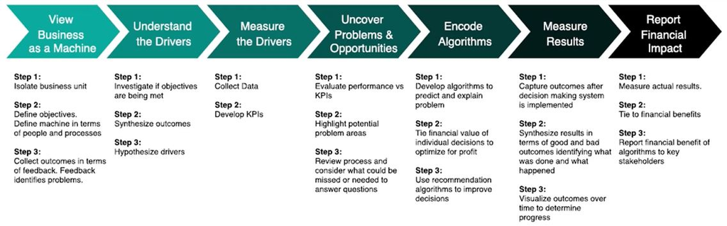

1. Business as a Machine

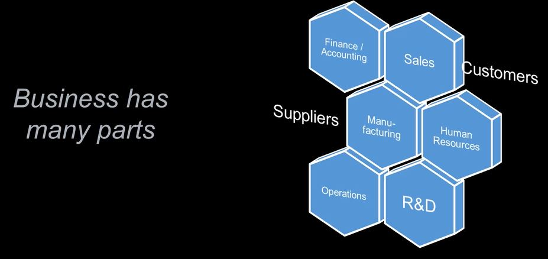

Each part of the business has Objectives –> Machine –> Outcomes.

- Objectives are the goals that serve a inputs or isntructions to the machine
- Machine - performs the work and is made of people and processes
  - If People or process is not right, the machine produces questionable output
  - People have biases
  - Process issues abound in all organizations
  - People/process design fit may be poor
- Outcomes - what the machine produces
  - Provides feedback to determine is the objectives are being met

> Our goal is to understnad the machine using data
2. Understand the Drivers
- Start with business objectives
  - Are goals being met or are ther problems?
- Syntehsize outcomes
  - turn positive and negative results into data
- Hypothesize drivers
  - hypothesize the drivers using hte data generated and suject matter experts, customers, stakeholders, etc
3. Measure the Drivers
- Collect data
  - Is data available?
  - Treat information as assets
    - sometimes applicaitons need to collect information-rich data to support analytic analysis. Becomes an organization asset.
  - Build stretgic data repositories
- Develop KPIs
  - Benchmark industry metrics
  - Develop internal metrics using goals
4. Uncover Problems & Opportunites
- Evaluate performance vs KPIs
  - Probem identification
  - Opportunites for data science & analytic decsion making

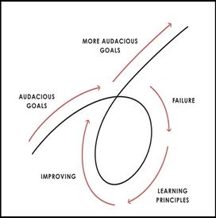

> When you have exhausted all possibilities, remember this - you haven’t.
- Thomas Jefferson
5. Encode Algorithms
- Develop algorithms
  - Predict target
  - Explain in terms of business levers
- Maximize profit
  - Optimization problem
  - Expected value framework - a method for making decisions based on the probability mutliplied by the expected finacial value of the decision
- Recommendation Systems
6. Measure the Results
- Capture outcomes
- Synthesize results - looking for progress
- Visualize over time
7. Report Financial Impact
- Every decsion has a financial value
- Change is only good if it improves financial performance
- Financial benefits **must** be reported on to justify any improvement

# 2 Chapter 1: Business Understanding: BSPF & Code Workflows

## 2.1 Chapter 1.1 Problem Understanding With BSPF

### 2.1.1 Business Understanding

The BSPF includes the following steps of the the CRISP-DM Framework:

1. View the Business as a Machine
2. Underestnad the Drivers
3. Measure the Drivers
4. Uncover Problems & Opportunities

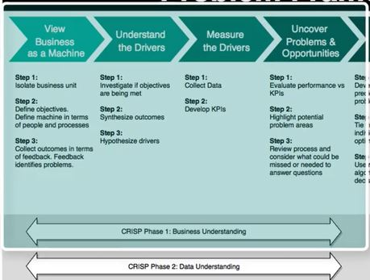

### 2.1.2 View The Business As A Machine

> Review business_understanding.R file in 01_Business Understanding folder

Business Units: Department and Job Role Define Objectives: Retain high performers Assess Outcomes: TBD - Feedback from the business

*Known* - 16.1% attrition in the current state - is this a bad thing?

### 2.1.3 Understand The Drivers, Part 1: By Dept

Investigate the Objectives: 16% Attrition Synthesize Outcomes: High counts and high percentages (learned after hypothesizing drivers). See below under *Understnad the Drivers*. Hypothesize Drivers: Job Role and Departments

```
## # A tibble: 6 x 4
## # Groups:   Department [3]
##   Department             Attrition     n   pct
##   <chr>                  <chr>     <int> <dbl>
## 1 Human Resources        No           37 0.755
## 2 Human Resources        Yes          12 0.245
## 3 Research & Development No          721 0.867
## 4 Research & Development Yes         111 0.133
## 5 Sales                  No          291 0.789
## 6 Sales                  Yes          78 0.211
```

Department and Job Roles are common cohorts to evaluate.

HR has 24% attrition, Sales 21% - might be something going on by department.

### 2.1.4 Understand The Drivers, Part 2: By Job Role

```r
dept_job_role_tbl %>% group_by(Department, JobRole, Attrition) %>%  summarise(n = n()) %>% ungroup() %>%
     group_by(Department, JobRole) %>% mutate(pct = n/sum(n)) %>% ungroup() %>% filter(Attrition %in% c("Yes"))
```

```
## # A tibble: 10 x 5
##    Department             JobRole                   Attrition     n    pct
##    <chr>                  <chr>                     <chr>     <int>  <dbl>
##  1 Human Resources        Human Resources           Yes          12 0.308
##  2 Research & Development Healthcare Representative Yes           8 0.0762
##  3 Research & Development Laboratory Technician     Yes          49 0.219
##  4 Research & Development Manager                   Yes           2 0.0417
##  5 Research & Development Manufacturing Director    Yes           7 0.0569
##  6 Research & Development Research Director         Yes           2 0.0274
##  7 Research & Development Research Scientist        Yes          43 0.166
##  8 Sales                  Manager                   Yes           2 0.0645
##  9 Sales                  Sales Executive           Yes          50 0.183
## 10 Sales                  Sales Representative      Yes          26 0.4
```

```r
# Used Attrition %in% instead of == because the former is more flexible - can add mutiple categories :  c("cat1", "cat2", . . .)
```

Note there are different roles with each department. Perhaps certain roles have greater attrition issues than others?  
Note the HR 30%; Note Sales Excutive - only 18.3% but there are 50 leaving; Sales Representative may be a problem too.

### 2.1.5 Measure The Drivers, Part 1: Collect Data

> Now in the BSPF - Measure the Drivers Step

This is an iterative task that is ongoing.

You may not have all the data initially. Further, you don’t want all the data since many of the features are a distraction prior to understanding if a problem exists. During the Business Understanding phase we need to isolate the critical features that relate to business outcomes and determine if a problem exists such that when solved it provides real value in terms of financial benefit.

There are 35 features to consider:

```r
names(train_raw_tbl)
```

```
##  [1] "Age"                      "Attrition"
##  [3] "BusinessTravel"           "DailyRate"
##  [5] "Department"               "DistanceFromHome"
##  [7] "Education"                "EducationField"
##  [9] "EmployeeCount"            "EmployeeNumber"
## [11] "EnvironmentSatisfaction"  "Gender"
## [13] "HourlyRate"               "JobInvolvement"
## [15] "JobLevel"                 "JobRole"
## [17] "JobSatisfaction"          "MaritalStatus"
## [19] "MonthlyIncome"            "MonthlyRate"
## [21] "NumCompaniesWorked"       "Over18"
## [23] "OverTime"                 "PercentSalaryHike"
## [25] "PerformanceRating"        "RelationshipSatisfaction"
## [27] "StandardHours"            "StockOptionLevel"
## [29] "TotalWorkingYears"        "TrainingTimesLastYear"
## [31] "WorkLifeBalance"          "YearsAtCompany"
## [33] "YearsInCurrentRole"       "YearsSinceLastPromotion"
## [35] "YearsWithCurrManager"
```

Some features related to one and other.

> It is always helpful to breakdown data collection activities in to strategic areas.
- Descriptive Features:
  - Age, DistanceFromHome, Gebder, MaritalStatus, NumComaniesWorked, Over18
- Employment Features:
  - Department, EmploeeCount, EmployeeNumber, JobInvolement, JobLevel, JobRole, JobSatistfaction
- Compensation Features:
  - DailyRate, HourlyRate, MonthlyIncome, MonthlyRate, PercentSalaryHike, StockOptionLevel
- Survey Results:
  - EnvironmentSatisfaction, JobSatisfaction, RelationshipSatisfaction, WorkLifeBalance
- Performance Data:
  - JobInvolvement, PerformanceRating
- Work-Life Balance
  - BusinessTravel, OverTime
- Training and Education
  - Education, EducationField, TrianingTimesLastYear
- Time-Based Features
  - TotalWorkingYears, YearsAtCompany, YearsInCurrentROle, YearsSinceLastPromotion, YearsWithCurrentManager

### 2.1.6 Measure The Drivers, Part 2: Develop KPIs

Often review turnover statistics in your industry. We know our is 16% but we do not know if this is good or bad without [research](http://www.air-prehire.com/blog/industries-high-employee-turnover-rates/.  
Perhaps it simply fails an internal KPI.

Via web searching, *8.8% average turnover for utility companies* (useful for this data). (Banking is around 17.2%)

```
## # A tibble: 10 x 6
##    Department      JobRole         Attrition     n    pct above_industry_~
##    <chr>           <chr>           <chr>     <int>  <dbl> <chr>
##  1 Sales           Sales Represen~ Yes          26 0.4    Yes
##  2 Human Resources Human Resources Yes          12 0.308  Yes
##  3 Research & Dev~ Laboratory Tec~ Yes          49 0.219  Yes
##  4 Sales           Sales Executive Yes          50 0.183  Yes
##  5 Research & Dev~ Research Scien~ Yes          43 0.166  Yes
##  6 Research & Dev~ Healthcare Rep~ Yes           8 0.0762 No
##  7 Sales           Manager         Yes           2 0.0645 No
##  8 Research & Dev~ Manufacturing ~ Yes           7 0.0569 No
##  9 Research & Dev~ Manager         Yes           2 0.0417 No
## 10 Research & Dev~ Research Direc~ Yes           2 0.0274 No
```

Note the Dept and Job Role with high percentages and counts. To make this more impactful, add cost to this table.